# SPSS Assignment 1: Data Quality and Reliability Analysis

**Jason O'Brien**  
**CI 7303 — Psychometric Methods**  
**22 March 2026**

This assignment walks through importing survey data, evaluating data quality, assessing internal consistency (Cronbach's alpha), and creating scale scores. Python is used in place of SPSS; all procedures are equivalent.

```python
import pandas as pd
import numpy as np
import pyreadstat
import matplotlib.pyplot as plt
from IPython.display import display, Markdown

# Load the practice data
df, meta = pyreadstat.read_sav('SPSSAssignment1_Practice_Data.sav')
print(f'Dataset: {df.shape[0]} observations, {df.shape[1]} variables')
df.head()
```

```
Dataset: 384 observations, 19 variables
```

|  | ID | sect16_2 | sect17_2_r | sect18_2 | sect19_2 | sect20_2_r | sect21_2 | sect22_2 | sect23_2 | sft70_2 | sft71_2 | sft72_2_r | sft73_2 | sft74_2 | Anxiety | InformationProcessing | Exam_Score | Homework_Score | CourseCredit |
| --- | --- | --- | --- | --- | --- | --- | --- | --- | --- | --- | --- | --- | --- | --- | --- | --- | --- | --- | --- |
| 0 | 3001.0 | 4.0 | 4.0 | 5.0 | 4.0 | 4.0 | 5.0 | 4.0 | 4.0 | 3.0 | 2.0 | 1.0 | 3.0 | 3.0 | 2.888889 | 2.777778 | 77.163067 | 44.218159 | 1.0 |
| 1 | 3002.0 | 3.0 | 3.0 | 4.0 | 4.0 | 3.0 | 4.0 | 4.0 | 4.0 | 3.0 | 5.0 | 5.0 | 3.0 | 3.0 | 1.888889 | 4.000000 | 58.389741 | 72.248523 | 0.0 |
| 2 | 3003.0 | 5.0 | 5.0 | 4.0 | 5.0 | 5.0 | 5.0 | 5.0 | 5.0 | 3.0 | 4.0 | 2.0 | 3.0 | 3.0 | 5.000000 | 2.777778 | 84.329808 | 98.737232 | 1.0 |
| 3 | 3004.0 | 5.0 | 5.0 | 5.0 | 4.0 | 5.0 | 4.0 | 5.0 | 4.0 | 4.0 | 2.0 | 5.0 | 3.0 | 4.0 | 2.888889 | 3.444444 | 71.864053 | 92.913460 | 1.0 |
| 4 | 3005.0 | 1.0 | 1.0 | 3.0 | 2.0 | 3.0 | 2.0 | 3.0 | 4.0 | 5.0 | 5.0 | 4.0 | 3.0 | 5.0 | 1.111111 | 4.666667 | 47.051978 | NaN | 0.0 |

## 1. Data Overview

The dataset contains two sets of scale items, pre-computed scale scores, and outcome variables:

| Variable Group | Variables | Description |
| --- | --- | --- |
| SECT items | `sect16_2` – `sect23_2` (8 items) | Scale items; `_r` = reverse-coded |
| SFT items | `sft70_2` – `sft74_2` (5 items) | Scale items; `_r` = reverse-coded |
| Pre-computed scales | `Anxiety`, `InformationProcessing` | Already-calculated scale scores |
| Outcomes | `Exam_Score`, `Homework_Score`, `CourseCredit` | Performance measures |

## 2. Descriptive Statistics (Means, SDs, Frequencies)

```python
# Means and standard deviations for all variables
desc = df.describe().T[['count', 'mean', 'std', 'min', '25%', '50%', '75%', 'max']]
desc = desc.round(3)
display(desc)
```

|  | count | mean | std | min | 25% | 50% | 75% | max |
| --- | --- | --- | --- | --- | --- | --- | --- | --- |
| ID | 384.0 | 3192.500 | 110.995 | 3001.000 | 3096.750 | 3192.500 | 3288.250 | 3384.0 |
| sect16_2 | 384.0 | 3.542 | 1.419 | 1.000 | 2.000 | 4.000 | 5.000 | 5.0 |
| sect17_2_r | 384.0 | 3.159 | 1.342 | 1.000 | 2.000 | 3.000 | 4.000 | 5.0 |
| sect18_2 | 384.0 | 3.607 | 1.202 | 1.000 | 3.000 | 4.000 | 5.000 | 9.0 |
| sect19_2 | 384.0 | 3.581 | 1.217 | 1.000 | 3.000 | 4.000 | 5.000 | 5.0 |
| sect20_2_r | 384.0 | 3.232 | 1.398 | 1.000 | 2.000 | 3.000 | 5.000 | 5.0 |
| sect21_2 | 377.0 | 3.101 | 1.331 | 1.000 | 2.000 | 3.000 | 4.000 | 5.0 |
| sect22_2 | 384.0 | 4.042 | 1.158 | 1.000 | 3.000 | 4.000 | 5.000 | 5.0 |
| sect23_2 | 384.0 | 3.888 | 1.108 | 1.000 | 3.000 | 4.000 | 5.000 | 5.0 |
| sft70_2 | 384.0 | 3.109 | 1.236 | 1.000 | 2.000 | 3.000 | 4.000 | 5.0 |
| sft71_2 | 384.0 | 3.013 | 1.227 | 0.000 | 2.000 | 3.000 | 4.000 | 5.0 |
| sft72_2_r | 384.0 | 3.201 | 1.278 | 1.000 | 2.000 | 3.000 | 4.000 | 5.0 |
| sft73_2 | 384.0 | 3.169 | 1.313 | 1.000 | 2.000 | 3.000 | 4.000 | 5.0 |
| sft74_2 | 371.0 | 3.668 | 1.208 | 1.000 | 3.000 | 4.000 | 5.000 | 5.0 |
| Anxiety | 384.0 | 2.627 | 1.082 | 1.000 | 1.778 | 2.611 | 3.361 | 5.0 |
| InformationProcessing | 384.0 | 3.346 | 0.745 | 1.111 | 2.778 | 3.333 | 3.889 | 5.0 |
| Exam_Score | 354.0 | 64.500 | 19.595 | 11.363 | 50.649 | 63.806 | 78.666 | 115.0 |
| Homework_Score | 379.0 | 55.774 | 26.492 | 0.000 | 38.324 | 56.464 | 73.001 | 150.0 |
| CourseCredit | 384.0 | 0.451 | 0.498 | 0.000 | 0.000 | 0.000 | 1.000 | 1.0 |

```python
# Frequency distributions for the scale items
sect_items = ['sect16_2', 'sect17_2_r', 'sect18_2', 'sect19_2', 'sect20_2_r', 'sect21_2', 'sect22_2', 'sect23_2']
sft_items = ['sft70_2', 'sft71_2', 'sft72_2_r', 'sft73_2', 'sft74_2']

print('=== SECT Item Frequencies ===')
for item in sect_items:
    print(f'\n{item}:')
    print(df[item].value_counts().sort_index())

print('\n=== SFT Item Frequencies ===')
for item in sft_items:
    print(f'\n{item}:')
    print(df[item].value_counts().sort_index())
```

```
=== SECT Item Frequencies ===

sect16_2:
sect16_2
1.0     56
2.0     41
3.0     55
4.0    103
5.0    129
Name: count, dtype: int64

sect17_2_r:
sect17_2_r
1.0    54
2.0    80
3.0    78
4.0    95
5.0    77
Name: count, dtype: int64

sect18_2:
sect18_2
1.0     26
2.0     33
3.0    117
4.0    102
5.0    105
9.0      1
Name: count, dtype: int64

sect19_2:
sect19_2
1.0     27
2.0     45
3.0    101
4.0    100
5.0    111
Name: count, dtype: int64

sect20_2_r:
```

[output cut: 67 more lines]

```
1.0     57
2.0     52
3.0    124
4.0     71
5.0     80
Name: count, dtype: int64

sft74_2:
sft74_2
1.0     21
2.0     41
3.0    103
4.0     81
5.0    125
Name: count, dtype: int64
```

### Interpretation

Most item means fall in the 3.0–4.0 range with standard deviations between 1.1 and 1.4, which is reasonable for 5-point Likert-type items. Two items stand out in the descriptive statistics as needing attention:

- **`sect18_2`** has a maximum of 9.0, which exceeds the 1–5 response scale.
- **`sft71_2`** has a minimum of 0.0, which falls below the 1–5 response scale.

These are non-plausible values and will be addressed in Section 4. Standard deviations are otherwise consistent across items, suggesting no ceiling or floor effects in the remaining data. The pre-computed `Anxiety` and `InformationProcessing` scores show means of 2.63 and 3.35 respectively, both within their expected ranges.

## 3. Missing Data

```python
# Missing data summary
missing = pd.DataFrame({
    'Valid': df.count(),
    'Missing': df.isnull().sum(),
    'Pct_Missing': (df.isnull().sum() / len(df) * 100).round(2)
})
display(missing[missing['Missing'] > 0])
print(f'\nVariables with no missing data: {(missing["Missing"] == 0).sum()} of {len(missing)}')
```

|  | Valid | Missing | Pct_Missing |
| --- | --- | --- | --- |
| sect21_2 | 377 | 7 | 1.82 |
| sft74_2 | 371 | 13 | 3.39 |
| Exam_Score | 354 | 30 | 7.81 |
| Homework_Score | 379 | 5 | 1.30 |

```
Variables with no missing data: 15 of 19
```

### Interpretation

Four variables have missing data. For the scale items, missingness is minimal: `sect21_2` is missing 7 cases (1.8%) and `sft74_2` is missing 13 cases (3.4%). Among the outcome variables, `Exam_Score` has the most missingness at 30 cases (7.8%), and `Homework_Score` is missing 5 cases (1.3%). The remaining 15 variables have complete data.

Missing data is distributed across different variables rather than concentrated in a single item or a single cluster of respondents, suggesting it is likely missing at random rather than systematically. At these rates, listwise deletion (the default in most analyses) will not meaningfully reduce statistical power or bias results.

**A note on missing data mechanisms.** Missing data falls into three categories, and which one applies determines how serious the problem is:

- **MCAR (Missing Completely At Random):** Missingness is unrelated to anything in the dataset. A server error drops records, or a respondent skips a question because they sneezed. No bias. This is the easiest case.
- **MAR (Missing At Random):** Missingness is related to an observed variable. Sophomores skip an item more often than seniors, but you can see class standing. Manageable with techniques like multiple imputation.
- **MNAR (Missing Not At Random):** Missingness is related to the missing value itself. A student with high anxiety skips the anxiety question. This is the dangerous case because the missingness is driven by the unobserved value, and no statistical technique can fully correct for it.

In this dataset, the pattern of missingness across unrelated variables is consistent with MCAR or MAR. There is no indication of MNAR.

## 4. Non-Plausible Values and Outliers

```python
# Check for non-plausible values in scale items (expected range: 1-5)
all_items = sect_items + sft_items
print('=== Non-Plausible Values (outside 1-5 range) ===')
for item in all_items:
    out_of_range = df[(df[item] < 1) | (df[item] > 5)][item]
    if len(out_of_range) > 0:
        print(f'\n  {item}: {len(out_of_range)} case(s)')
        print(f'    Values: {out_of_range.values}')
        print(f'    IDs: {df.loc[out_of_range.index, "ID"].values}')
```

```
=== Non-Plausible Values (outside 1-5 range) ===

  sect18_2: 1 case(s)
    Values: [9.]
    IDs: [3102.]

  sft71_2: 1 case(s)
    Values: [0.]
    IDs: [3334.]
```

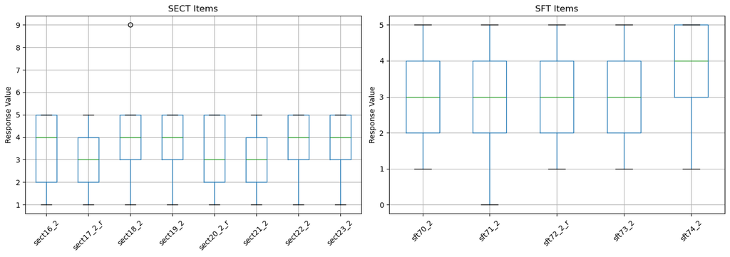

```python
# Boxplots for scale items
fig, axes = plt.subplots(1, 2, figsize=(14, 5))

df[sect_items].boxplot(ax=axes[0], rot=45)
axes[0].set_title('SECT Items')
axes[0].set_ylabel('Response Value')

df[sft_items].boxplot(ax=axes[1], rot=45)
axes[1].set_title('SFT Items')
axes[1].set_ylabel('Response Value')

plt.tight_layout()
plt.show()
```

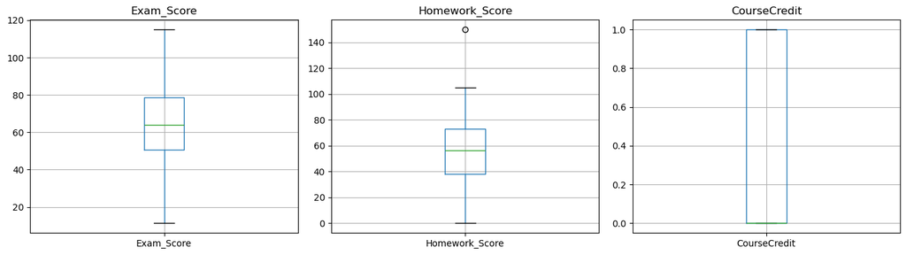

```python
# Boxplots for outcome variables
fig, axes = plt.subplots(1, 3, figsize=(14, 4))

for ax, var in zip(axes, ['Exam_Score', 'Homework_Score', 'CourseCredit']):
    df[[var]].boxplot(ax=ax)
    ax.set_title(var)

plt.tight_layout()
plt.show()
```

### Interpretation

Two non-plausible values were identified in the scale items:

1. **`sect18_2`, ID 3102: value = 9.** This exceeds the 1–5 response range and cannot represent a valid response. It is a data entry error.
2. **`sft71_2`, ID 3334: value = 0.** This falls below the 1–5 response range. The lowest valid response is 1.

These are not outliers (extreme but possible values); they are **impossible values** on the measurement scale. Because no valid interpretation exists for these responses, they are recoded to missing (`NaN`) rather than imputed. Imputation assumes a true score exists to be estimated — for an impossible value, there is no underlying true score to recover.

The boxplots for the outcome variables show some extreme values (e.g., `Homework_Score` near 150, `Exam_Score` above 100). These may represent legitimate performance outcomes (extra credit, bonus points) or errors, but without additional context about the scoring rubric, they are retained and flagged for consideration.

```python
# Recode non-plausible values to NaN
print('Before cleaning:')
print(f'  sect18_2 max: {df["sect18_2"].max()}')
print(f'  sft71_2 min: {df["sft71_2"].min()}')

# sect18_2: value of 9 is impossible on a 1-5 scale
df.loc[df['sect18_2'] > 5, 'sect18_2'] = np.nan

# sft71_2: value of 0 is impossible on a 1-5 scale
df.loc[df['sft71_2'] < 1, 'sft71_2'] = np.nan

print('\nAfter cleaning:')
print(f'  sect18_2 max: {df["sect18_2"].max()}, missing: {df["sect18_2"].isnull().sum()}')
print(f'  sft71_2 min: {df["sft71_2"].min()}, missing: {df["sft71_2"].isnull().sum()}')
```

```
Before cleaning:
  sect18_2 max: 9.0
  sft71_2 min: 0.0

After cleaning:
  sect18_2 max: 5.0, missing: 1
  sft71_2 min: 1.0, missing: 1
```

## 5. Reliability Analysis (Cronbach's Alpha)

```python
def cronbachs_alpha(items_df):
    """Calculate Cronbach's alpha for a set of items."""
    items = items_df.dropna()
    k = items.shape[1]
    item_vars = items.var(ddof=1)
    total_var = items.sum(axis=1).var(ddof=1)
    alpha = (k / (k - 1)) * (1 - item_vars.sum() / total_var)
    return alpha

def alpha_if_deleted(items_df):
    """Calculate alpha-if-item-deleted and corrected item-total correlations."""
    items = items_df.dropna()
    results = []
    total = items.sum(axis=1)

    for col in items.columns:
        # Alpha if this item is deleted
        remaining = items.drop(columns=[col])
        a = cronbachs_alpha(remaining)

        # Corrected item-total correlation (correlation with total minus this item)
        corrected_total = total - items[col]
        r = items[col].corr(corrected_total)

        results.append({'Item': col, 'Alpha_if_Deleted': round(a, 4), 'Corrected_Item_Total_r': round(r, 4)})

    return pd.DataFrame(results)
```

```python
# SECT scale reliability (after cleaning non-plausible values)
sect_alpha = cronbachs_alpha(df[sect_items])
print(f'SECT Scale — Cronbach\'s Alpha: {sect_alpha:.4f}')
print(f'Number of items: {len(sect_items)}')
print()

sect_aid = alpha_if_deleted(df[sect_items])
display(sect_aid)
```

```
SECT Scale — Cronbach's Alpha: 0.8564
Number of items: 8
```

|  | Item | Alpha_if_Deleted | Corrected_Item_Total_r |
| --- | --- | --- | --- |
| 0 | sect16_2 | 0.8422 | 0.5807 |
| 1 | sect17_2_r | 0.8358 | 0.6276 |
| 2 | sect18_2 | 0.8344 | 0.6457 |
| 3 | sect19_2 | 0.8411 | 0.5828 |
| 4 | sect20_2_r | 0.8399 | 0.5965 |
| 5 | sect21_2 | 0.8406 | 0.5884 |
| 6 | sect22_2 | 0.8393 | 0.6016 |
| 7 | sect23_2 | 0.8403 | 0.5951 |

```python
# SFT scale reliability (after cleaning non-plausible values)
sft_alpha = cronbachs_alpha(df[sft_items])
print(f'SFT Scale — Cronbach\'s Alpha: {sft_alpha:.4f}')
print(f'Number of items: {len(sft_items)}')
print()

sft_aid = alpha_if_deleted(df[sft_items])
display(sft_aid)
```

```
SFT Scale — Cronbach's Alpha: 0.6626
Number of items: 5
```

|  | Item | Alpha_if_Deleted | Corrected_Item_Total_r |
| --- | --- | --- | --- |
| 0 | sft70_2 | 0.6082 | 0.4215 |
| 1 | sft71_2 | 0.6056 | 0.4274 |
| 2 | sft72_2_r | 0.6247 | 0.3860 |
| 3 | sft73_2 | 0.6103 | 0.4179 |
| 4 | sft74_2 | 0.6065 | 0.4259 |

### 6. Interpretation: Alpha if Item Deleted

**SECT Scale (α = .856, 8 items) — Good reliability.**

All alpha-if-item-deleted values fall below the overall alpha of .856, meaning no individual item weakens the scale. If any item's removal caused alpha to increase, that would signal the item is inconsistent with the rest. Here, the opposite is true — every item contributes to internal consistency. Corrected item-total correlations range from .58 to .65, indicating each item correlates moderately-to-strongly with the composite of the remaining items. This is a well-functioning scale.

**SFT Scale (α = .663, 5 items) — Below the conventional .70 threshold.**

## 7. Create Scale Scores

```python
# Mean scale scores (recommended approach)
df['SECT_Mean'] = df[sect_items].mean(axis=1)
df['SFT_Mean'] = df[sft_items].mean(axis=1)

print('=== New Scale Score Descriptives ===')
display(df[['SECT_Mean', 'SFT_Mean']].describe().round(3))
```

```
=== New Scale Score Descriptives ===
```

|  | SECT_Mean | SFT_Mean |
| --- | --- | --- |
| count | 384.000 | 384.000 |
| mean | 3.518 | 3.229 |
| std | 0.900 | 0.819 |
| min | 1.125 | 1.400 |
| 25% | 2.875 | 2.600 |
| 50% | 3.625 | 3.200 |
| 75% | 4.250 | 3.800 |
| max | 5.000 | 5.000 |

## 8. Final Verification

```
=== Scale Score Missing Data ===
SECT_Mean: 0 missing (0.0%)
SFT_Mean: 0 missing (0.0%)
```

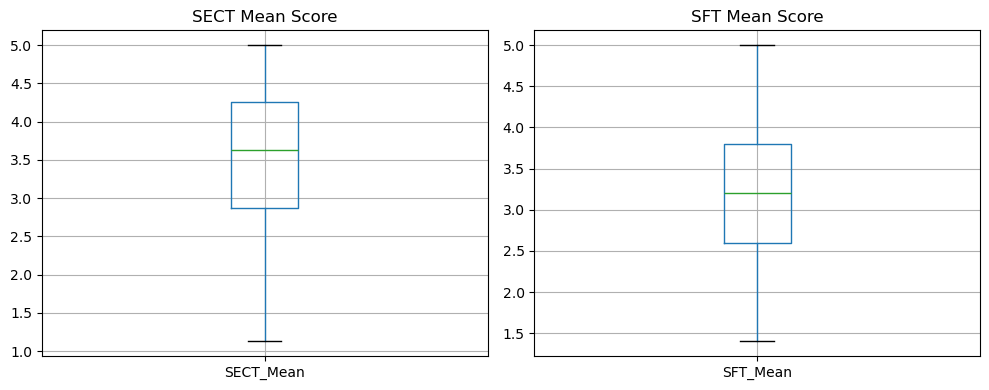

```python
# Check scale scores for missing data and outliers
print('=== Scale Score Missing Data ===')
for scale in ['SECT_Mean', 'SFT_Mean']:
    n_missing = df[scale].isnull().sum()
    print(f'{scale}: {n_missing} missing ({n_missing/len(df)*100:.1f}%)')

print()

# Boxplots of final scale scores
fig, axes = plt.subplots(1, 2, figsize=(10, 4))
df[['SECT_Mean']].boxplot(ax=axes[0])
axes[0].set_title('SECT Mean Score')
df[['SFT_Mean']].boxplot(ax=axes[1])
axes[1].set_title('SFT Mean Score')
plt.tight_layout()
plt.show()
```

## Summary and Interpretation

### Data Quality

The dataset contained 384 observations across 19 variables. Two non-plausible values were identified in the scale items: a response of 9 on `sect18_2` (ID 3102) and a response of 0 on `sft71_2` (ID 3334). Both fall outside the valid 1–5 response range and were recoded to missing as data entry errors. Missing data across the dataset was minimal (1.3%–7.8% on affected variables) and distributed across different variables, consistent with data missing at random.

### Reliability

The **SECT scale** (8 items) demonstrated good internal consistency (α = .856). All items contributed positively to scale reliability, with corrected item-total correlations between .58 and .65. No items were flagged for removal.

### Scale Scores

Mean scale scores were computed for both scales. The SECT mean score (M = 3.52, SD = 0.90) and SFT mean score (M = 3.23, SD = 0.82) both fall near the midpoint of the 1–5 range, indicating adequate variability in the sample. Neither scale score showed evidence of floor or ceiling effects.

### Deliverables

| Deliverable | Status |
| --- | --- |
| Descriptive statistics table | Section 2 |
| Reliability output (Cronbach's alpha) | Section 5 |
| Interpretation of weak items | Section 6 |
| Final scale scores | Section 7–8 |

## AI Use Disclosure

This assignment was completed using Claude (Anthropic) as a collaborative tool through the Claude Code CLI. The AI assisted with:

- **Code execution:** Python was used in place of SPSS. Claude wrote the analysis code (pyreadstat for data import, pandas for descriptives, custom functions for Cronbach's alpha and alpha-if-item-deleted).
- **Interpretation drafting:** Initial interpretations were drafted by Claude and then reviewed, discussed, and revised through a Socratic dialogue process.
- **Concept reinforcement:** Key concepts (Cronbach's alpha, non-plausible values vs. outliers, missing data patterns, mean vs. sum scoring) were discussed before interpretations were finalized.

**What I did:** Directed the analysis, identified what needed to be done at each step, explained my understanding of each concept before Claude drafted interpretations, caught and corrected conceptual gaps, and made final editorial decisions. I reviewed all output and confirmed that interpretations matched my understanding of the material.

**What Claude did:** Wrote the Python code, generated statistical output, drafted interpretation text based on our discussions, and connected psychometric concepts to my professional context.

**Process documentation:** A detailed experiment log documenting every interaction, concept discussion, and decision point is maintained at `for_jason/coursework-ai-experiment-log.md` and version-controlled via git. This log records my initial understanding of each concept, where corrections were needed, and what was reinforced — serving as evidence that the learning process, not just the output, was the focus of this work.